### Sentiment scores of movie reviews

```
library(sentiment)
library(dplyr)
library(plyr)
library(syuzhet)
library(ggplot2)
library(caret)
library(text2vec)
library(tm)
library(wordcloud)
```

情感分析除了分析極性(polarity)，情緒(emotion)分數也是一個重要指標。前次練習使用不同的分類方法處理極性問題，這次主要利用2種套件(syuzhet, sentiment)方法和 lexicon 來完成，一樣使用 [labeledTrainData.tsv](https://www.kaggle.com/c/word2vec-nlp-tutorial/data) 的 25000 筆資料，在極性方面，目的是了解方法使用結果與實際的差異，在情緒方面，幫助了解整體影評的情緒比例，最後呈現相關emotion字詞…

#### **Get sentiment polarity / emotion scores**

首先使用 syuzhet 套件，將前處理後的影評資料(含id和reviews欄位的dataframe)透過以下方法，擷取每則 review 的 polarity 分數，這裡使用4種lexicons方法(nrc, bing, afinn & syuzhet)

```r
# 將文件斷句, 加總取得每文件的sentiment polarity
sentimentDocAll <- function(df){
  emo.m = ddply(df, .(id), function(x) {
    s_v = get_sentences(x$review2)
    s_v = as.character(s_v)
    m1 = sum(get_sentiment(s_v, method= 'nrc'))
    m2 = sum(get_sentiment(s_v, method= 'bing'))
    m3 = sum(get_sentiment(s_v, method= 'afinn'))
    m4 = sum(get_sentiment(s_v, method= 'syuzhet'))
    return(cbind(nrc = m1, bing = m2, afinn = m3, syuzhet = m4))
  })
  return(emo.m)
}
```

下面是前10筆 reviews 的 polarity 分數，不同的 lexicons 得分結果也不相同

```
##        id nrc bing afinn syuzhet
## 1     0_3  -4   -3     6   -2.15
## 2     0_9   4    0    -1    2.90
## 3     1_1  -5   -9    -3   -4.20
## 4     1_7   2    2     7    2.40
## 5    10_2   4    3     2    3.60
## 6    10_9   8    7    14    6.50
## 7   100_3  -3   -1     1    0.90
## 8   100_7  12   -1     1    5.00
## 9  1000_4   4   -4    -3   -0.05
## 10 1000_8   2    1     7    3.05
```

4種lexicons方法的分數與頻率分佈，bing 結果分佈的對稱性感覺較好 (原始資料的標籤正負評比為0.5/0.5)

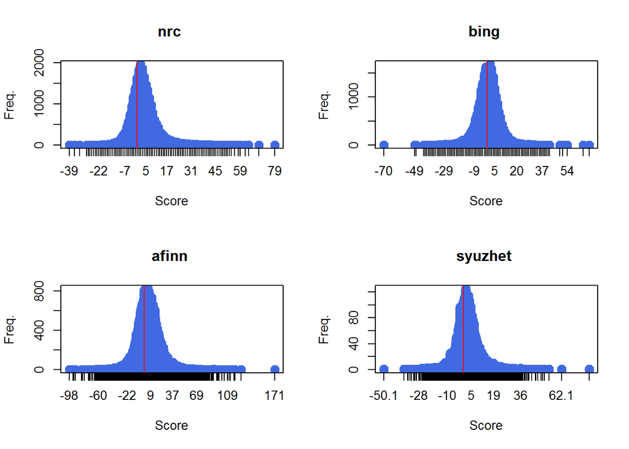

除了 polarity 分數，套件也提供 get_nrc_sentiment 方法可以得到 [NRC lexicon](http://saifmohammad.com/WebPages/NRC-Emotion-Lexicon.htm) 的 emotions 分數，以下方法計算每個句子的 emotions 分數

```r
# 裂解文件成句,取得每句emo分數
nrcEmotionSentence <- function(df){
  emo.m = ddply(df, .(id), function(x) {
    s_v = get_sentences(x$review2)
    s_v = as.character(s_v)
    emo = get_nrc_sentiment(s_v)
    return(cbind(s_v, emo))
  })
  return(emo.m)
}
```

前10個句子的 emotions 得分，可看出除了 negative 和 positive，NRC 將 emotions 分成8種(anger, anticipation, disgust, fear, joy, sadness & surprise)

```
##     id anger anticipation disgust fear joy sadness surprise trust negative
## 1  0_3     0            0       2    1   0       0        0     0        2
## 2  0_3     0            0       0    0   0       1        0     0        1
## 3  0_3     5            1       1    4   1       2        1     1        4
## 4  0_3     0            1       0    0   0       0        0     1        1
## 5  0_3     0            0       0    0   0       0        0     0        0
## 6  0_3     0            1       0    0   1       0        1     2        0
## 7  0_3     0            0       0    0   0       0        1     0        0
## 8  0_9     0            0       0    0   0       0        0     0        0
## 9  0_9     0            1       0    0   0       0        0     1        0
## 10 0_9     0            0       0    0   0       0        0     0        0
##    positive
## 1         0
## 2         0
## 3         1
## 4         1
## 5         0
## 6         2
## 7         0
## 8         0
## 9         0
## 10        2
```

接著利用 sentiment 套件，classify_polarity 方法可以幫助得到每則 review 的 positive 和 negative (前10筆如下)，為了與原始資料的標籤(0:負評,1:正評)比較，採用 POS/NEG 大於1者為正評的規則，反之為負評

```
##       POS                NEG                POS/NEG             BEST_FIT
##  [1,] "83.3937591850633" "61.576129405347"  "1.35431960388569"  "neutral"
##  [2,] "57.3680351089082" "53.2392597680621" "1.07755132882826"  "neutral"
##  [3,] "60.1406238311479" "114.369935951297" "0.525842944047449" "negative"
##  [4,] "58.754329470028"  "62.269276585907"  "0.943552465861239" "negative"
##  [5,] "84.0869063656233" "71.2992934037519" "1.17935118780852"  "neutral"
##  [6,] "73.5632725254117" "17.8123396772424" "4.12990510277537"  "positive"
##  [7,] "34.1148997549927" "54.625554129182"  "0.624522721990438" "negative"
##  [8,] "128.513735531774" "141.459986404831" "0.908481181130561" "negative"
##  [9,] "67.1985217685598" "96.3099023156067" "0.697732218109316" "negative"
## [10,] "34.1148997549927" "34.4860789518123" "0.989236839672663" "negative"
```

classify_emotion 方法可幫助得到每則 review 的 emotions 分數，sentiment 套件將 emotions 分成6種(anger, disgust, fear, joy, sadness & surprise)，每則 review 對應一個 BEST_FIT emotion

```
##       ANGER              DISGUST            FEAR
##  [1,] "7.34083555412328" "3.09234031207392" "2.06783599555953"
##  [2,] "7.34083555412328" "3.09234031207392" "2.06783599555953"
##  [3,] "7.34083555412328" "7.34083555412328" "2.06783599555953"
##  [4,] "7.34083555412328" "3.09234031207392" "2.06783599555953"
##  [5,] "13.2129533435987" "3.09234031207392" "2.06783599555953"
##  [6,] "1.46871776464786" "3.09234031207392" "2.06783599555953"
##  [7,] "1.46871776464786" "3.09234031207392" "7.34083555412328"
##  [8,] "7.34083555412328" "3.09234031207392" "2.06783599555953"
##  [9,] "1.46871776464786" "3.09234031207392" "2.06783599555953"
## [10,] "13.2129533435987" "3.09234031207392" "2.06783599555953"
##       JOY                SADNESS            SURPRISE           BEST_FIT
##  [1,] "13.6561935556456" "1.7277074477352"  "7.34083555412327" "joy"
##  [2,] "7.34083555412328" "12.9539636605113" "2.78695866252273" "sadness"
##  [3,] "1.02547755260094" "1.7277074477352"  "2.78695866252273" "anger"
##  [4,] "13.6561935556456" "7.34083555412328" "7.34083555412327" "joy"
##  [5,] "13.6561935556456" "7.34083555412328" "2.78695866252273" "joy"
##  [6,] "13.6561935556456" "1.7277074477352"  "2.78695866252273" "joy"
##  [7,] "1.02547755260094" "1.7277074477352"  "7.34083555412327" "fear"
##  [8,] "13.6561935556456" "1.7277074477352"  "2.78695866252273" "joy"
##  [9,] "26.2869095586903" "12.9539636605113" "7.34083555412327" "joy"
## [10,] "1.02547755260094" "1.7277074477352"  "2.78695866252273" "anger"
```

#### **Class-wise accuracy**

計算完每則 review 的 polarity 分數，自訂規則為得分小於0者屬於負評:0，反之為正評:1。接著與原始資料的標籤進行比對，syuzhet 套件4種 lexicons 方法的 Accuracy 如下，其中以 Bing Liu lexicon 的 0.72544 為最高

```r
nrc_accuracy <- confusionMatrix(ifelse(reviews_All$nrc < 0 , 0, 1), reviews_All$sentiment, positive = '1')
bing_accuracy <- confusionMatrix(ifelse(reviews_All$bing < 0 , 0, 1), reviews_All$sentiment, positive = '1')
afinn_accuracy <- confusionMatrix(ifelse(reviews_All$afinn < 0 , 0, 1), reviews_All$sentiment, positive = '1')
syuzhet_accuracy <- confusionMatrix(ifelse(reviews_All$syuzhet < 0 , 0, 1), reviews_All$sentiment, positive = '1')
# Accuracy比較
as.data.frame(list(nrc = nrc_accuracy$overall[1], bing = bing_accuracy$overall[1],
                   afinn = afinn_accuracy$overall[1], syuzhet = syuzhet_accuracy$overall[1]))
```

```
##              nrc    bing   afinn syuzhet
## Accuracy 0.63504 0.72544 0.68792 0.68272
```

sentiment 套件所得的 polarity 與原始資料的標籤比對，得到 Accuracy: 0.69164

```r
acc_sen <- confusionMatrix(sen_polarity, reviews_All$sentiment, positive = '1')
acc_sen$overall[1]
```

```
## Accuracy
##  0.69164
```

此外，比較一下和 sentiment 套件結果的 cosine 相似度，發現 syuzhet 方法應用在這資料上與 sentiment 套件結果有約 0.83 的相似度

```r
# 與 sentiment套件polarity 結果相似度比較
nrc_sim = sim2(x = matrix(ifelse(reviews_All$nrc < 0 , 0, 1), 1),
               y = matrix(sen_polarity, 1), method = "cosine", norm = "l2")
bing_sim = sim2(x = matrix(ifelse(reviews_All$bing < 0 , 0, 1), 1),
                y = matrix(sen_polarity, 1), method = "cosine", norm = "l2")
afinn_sim = sim2(x = matrix(ifelse(reviews_All$afinn < 0 , 0, 1), 1),
                 y = matrix(sen_polarity, 1), method = "cosine", norm = "l2")
syuzhet_sim = sim2(x = matrix(ifelse(reviews_All$syuzhet < 0 , 0, 1), 1),
                   y = matrix(sen_polarity, 1), method = "cosine", norm = "l2")

as.data.frame(list(nrc = nrc_sim, bing = bing_sim, afinn = afinn_sim, syuzhet = syuzhet_sim))
```

```
##         nrc      bing     afinn   syuzhet
## 1 0.7972098 0.8262083 0.8090264 0.8275461
```

#### **Emotions dashboard**

由於原始資料並無 emotion 的標籤可供比對，無法得知確切的 Accuracy，不過繪出整體 reviews 的情緒比例對於參考是有幫助的，以下是NRC方法結果下的8種情緒比例

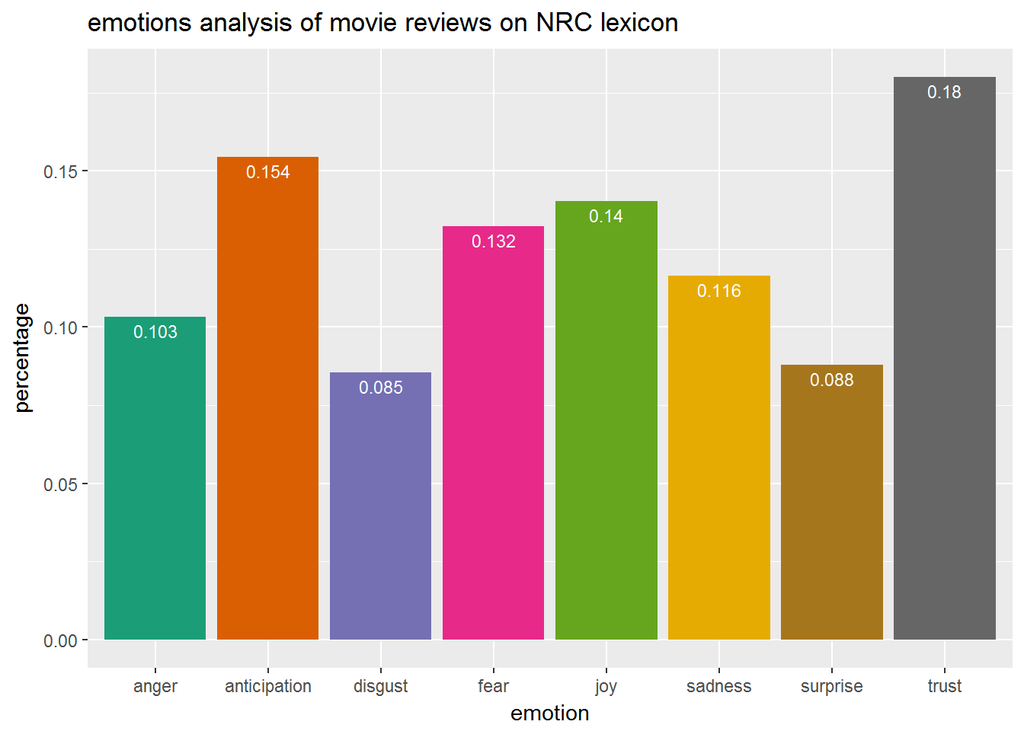

sentiment 套件方法結果的6種情緒比例，joy 的相對比非常的高

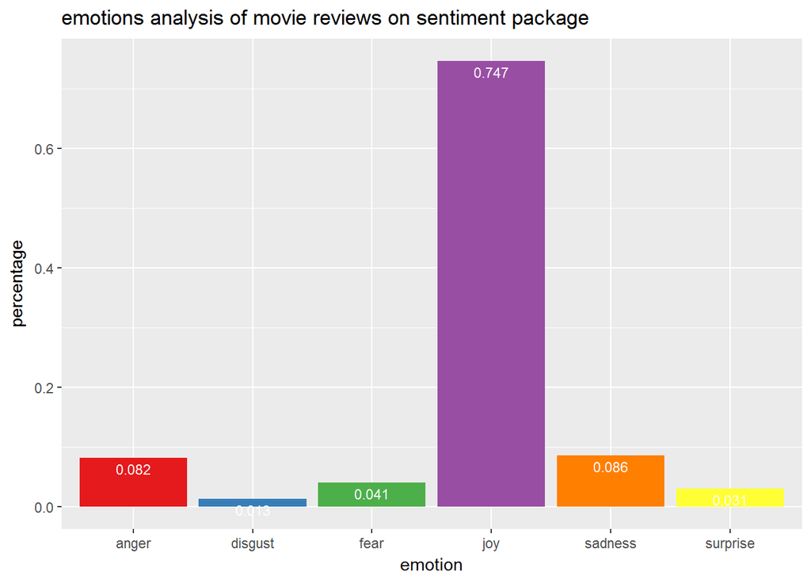

此外，為了定義每則 review 所屬的 emotion，自訂規則採分數最高的第一位者得，此做法為方便接下來繪製的情緒字雲

```r
# BestFitEmotion
bestFitEmotion <- function(df){
  fitemo.m = ddply(df, .(id_v), function(x) {
    rmax = which(x[-1]==max(x[-1]))[1]
    fitemo = colnames(x[-1])[rmax]
    return(fitemo)
  })
  return(fitemo.m)
}
```

```
##   id_v anger anticipation disgust fear joy sadness surprise trust
## 1  0_3     5            3       3    5   2       3        3     4
## 2  0_9     0            3       1    0   0       2        1     3
## 3  1_1     5            2       6    6   1       3        0     5
## 4  1_7     2            5       1    1   4       0        3     7
## 5 10_2     5            5       3    2   4       2        4     5
## 6 10_9     1            2       1    1   5       1        1     4
```

最後，將 syuzhet 套件 get_nrc_sentiment 方法的結果(如上)，結合上述 bestFitEmotion 函數，每一則 review 就有特定的 emotion 標籤，之後再利用 tm 與 wordcloud 套件產出NRC 8種情緒的字雲

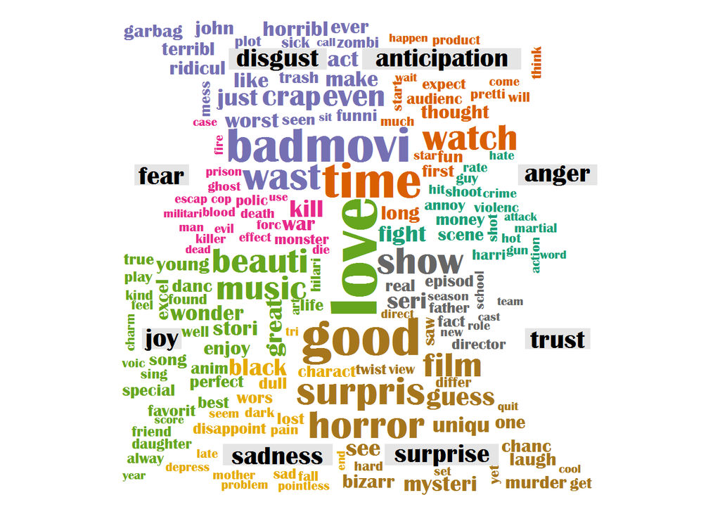

利用 sentiment 套件方法的結果，產出的6種情緒字雲

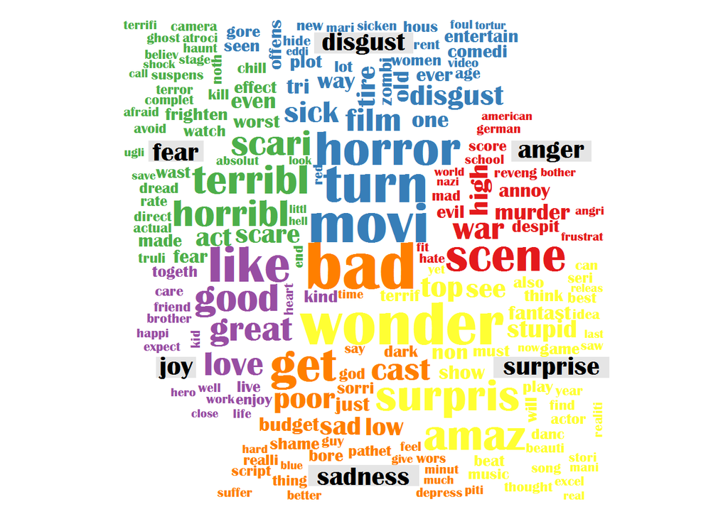

#### **Summary**

這次練習主要focus在 syuzhet 和 sentiment 套件，利用 lexicons 進行簡單的匹對，找出每一則 review 所屬的極性，之後再與原始資料的標籤值比對，得到以下的結果。從結果看來 movie reviews 的資料應用 simple matching lexicons 方法所得到的 accuracy 可以比 sentiment 套件的 naive Bayes 方法還要好，例如使用 Bing Liu lexicon 得到的 0.72544，其他 lexicons 的 accuracy 也有一定的準度(雖然不是很高)，這也顯示如果在沒有充足訓練資料前提下分析情感，simple matching 不失為一種選擇考量。在 emotions 分析上，雖然沒有標籤資料佐證準度，透過圖表方式有助於整體資料情緒的解讀，最後透過字雲，更將整體影評的情緒關鍵字濃縮呈現

| package | lexicon | method | accuracy |
| --- | --- | --- | --- |
| syuzhet | nrc | simple matching | 0.63504 |
|  | bing | simple matching | 0.72544 |
|  | afinn | simple matching | 0.68792 |
|  | syuzhet | simple matching | 0.68272 |
| sentiment | Janyce Wiebe’s subjectivity | naive Bayes | 0.69164 |

### Lessons Learned:

#### Sentiment analysis (polarity, emotion)

#### syuzhet, sentiment packages